# Discussion 12-Solution: ANOVA

Henry Mendoza Rivera, UW-Madison, Department of Statistics.

# Problem 1

Reading levels vary between different magazines. To avoid difficulties caused by different typefaces and sizes, an investigator just counted the number of letters and punctuation signs. Random samples of 20 sentences were selected from The New Yorker, Sports Illustrated, and National Geographic and the number of letters and punctuation signs in each were tabulated. The resulting summary statistics are:

| New Yorker | Sports Illustrated | National Geographic |
| --- | --- | --- |
| $\bar{y_1}=94.4$ | $\bar{y_2}=92.9$ | $\bar{y_3}=75.5$ |
| $s_1=58.4$ | $s_2=54.2$ | $s_3=38.1$ |
| $n_1=20$ | $n_2=20$ | $n_3 =20$ |

Note: $s_i^2=\sum^{n_i}_{i=1}\frac{(y_{ij}-\bar{y_i})^2}{(n_i-1)}$

A. In order to perform an ANOVA F test, what assumptions must be reasonably met? Check any of these assumptions you can.

**ANSWER: We need to assume that the number of letters and punctuation signs in each sentence from the three magazines are approximately normal (we can’t check this assumption with just summary measures) and that the variance of the three populations are approximately equal. We can see that the largest and smallest SDs are within a factor of 2, so this seems like a reasonable assumption. We must also assume the three groups are independent populations and the sentences within each sample are randomly chosen/independent for each.**

B. Construct the ANOVA table for this data and perform the relevant F test (assume that the necessary assumptions are reasonably met.)

| Source of Variation | Df | Sum Sq | Mean Sq | F Value | Pr(>F) |
| --- | --- | --- | --- | --- | --- |
| Treatments | 2 | 4414.8 | 2207.4 | 0.8490206 |  |
| Residuals | 57 | 148196.4 | 2599.937 |  |  |
| Total | 59 | 152611.2 |  |  |  |

$F=\frac{MSTrt}{MSError}=\frac{2207.4}{2599.937}=0.8490206$. $P(F_{2,57}>0.8490206)=0.4331721$. Greater than 10% can be read off F table. Fail to reject null. No evidence group means are different.

```r
#Question 1 Calculations
mean.ny=94.4; sd.ny=58.4; n.ny=20
mean.si=92.9; sd.si=54.2; n.si=20
mean.ng=75.5;  sd.ng=38.1; n.ng=20

SSErr=(n.ny-1)*sd.ny^2+(n.si-1)*sd.si^2+(n.ng-1)*sd.ng^2
Ov.mean=(n.ny*mean.ny+n.si*mean.si+n.ng*mean.ng)/(n.ny+n.si+n.ng)
SSTrt=n.ny*(mean.ny-Ov.mean)^2+n.si*(mean.si-Ov.mean)^2+n.ng*(mean.ng-Ov.mean)^2
SSTot=SSErr+SSTrt
MSErr=SSErr/57
MSTrt=SSTrt/2
Fstat=MSTrt/MSErr
pf(Fstat, 2, 57, lower.tail=FALSE)
```

```
## [1] 0.4331721
```

## Problem 2.

Consider the experiment where we are interested in determining the dose-response rates between several antibiotics applied at the same concentration. Treatments are randomly applied to cultured bacteria, and the percent reductions in bacterial population are given:

T1: 13.3, 13.7, 11.6, 11.9, 12.0, 12.9, 12.3, 12.1, 12.3, 12.3

T2: 12.5, 13.9, 12.4, 14.0, 12.8

T3: 16.8, 16.6, 17.1, 14.6, 17.4, 16.5

T4: 13.2, 14.2, 13.5, 13.2, 14.3, 12.7, 14.9, 13.3, 13.5

A. Test the claim that there is difference between the treatments at 5% significance level. Follow the steps given in the lecture.

## 1. `Step 1:` State null and alternative hypotheses and the significance level

1. `Claim`: “there is difference between the treatments.”
2. The random variables involved in the claim are:

$$\begin{align}
Y_{1j}:&\; \textrm{ percent reductions in bacterial population in cultured bacteria j under the Treatment 1}\\
Y_{2j}:&\; \textrm{percent reductions in bacterial population in cultured bacteria j under the Treatment 2}\\
Y_{3j}:&\; \textrm{percent reductions in bacterial population in cultured bacteria j under the Treatment 3}\\
Y_{4j}:&\; \textrm{percent reductions in bacterial population in cultured bacteria j under the Treatment 4}\\
\end{align}$$

3. The parameter of interest

$$\begin{align}
\textrm{Variable}\; Y_{1j}:&\; \textrm{The parameter is}\; \mu_{1}\; \textrm{(the population mean for treatment 1)} \\
\textrm{Variable}\; Y_{2j}:&\; \textrm{The parameter is}\; \mu_{2}\; \textrm{(the population mean for treatment 2)} \\
\textrm{Variable}\; Y_{3j}:&\; \textrm{The parameter is}\; \mu_{3}\;\textrm{(the population mean for treatment 3)} \\
\textrm{Variable}\; Y_{4j}:&\; \textrm{The parameter is}\; \mu_{4}\;\textrm{(the population mean for treatment 4)} \\
\end{align}$$

4. The claim in symbolic form is: $\mu_{i} \neq\mu_{i'}$ for any two different pairs of treatment i, i’. Or at least one mean differs from the other mean.
5. The claim in symbolic form that must be opposite to the original claim is : $\mu_{1}= \mu_{2}=\mu_{3}=\mu_{4}$
6. The null hypothesis and alternative hypotheses
   $$\bbox[#ffcc99,20px,border:10px ligth red]
   {
   H_{0}: \mu_{1}= \mu_{2}=\mu_{3}=\mu_{4} \;\;\textrm{vs}\;\;H_{A}: \textrm{At least one mean differs from the other mean}
   }$$

# `Step 2:` Data exploration

## Enter the data

Let denote the treatments 1,2,3 and 4 by T1, T2, T3, and T4, respectively.

```r
T1<-c(13.3,13.7,11.6,11.9,12.0,12.9,12.3,12.1,12.3,12.3)
T2<-c(12.5,13.9,12.4,14.0,12.8)
T3<-c(16.8,16.6,17.1,14.6,17.4,16.5)
T4<-c(13.2,14.2,13.5,13.2,14.3,12.7,14.9,13.3,13.5)
```

## Numerical Summary

```r
summary(T1)
```

```
##    Min. 1st Qu.  Median    Mean 3rd Qu.    Max.
##   11.60   12.03   12.30   12.44   12.75   13.70
```

```r
summary(T2)
```

```
##    Min. 1st Qu.  Median    Mean 3rd Qu.    Max.
##   12.40   12.50   12.80   13.12   13.90   14.00
```

```r
summary(T3)
```

```
##    Min. 1st Qu.  Median    Mean 3rd Qu.    Max.
##   14.60   16.52   16.70   16.50   17.02   17.40
```

```r
summary(T4)
```

```
##    Min. 1st Qu.  Median    Mean 3rd Qu.    Max.
##   12.70   13.20   13.50   13.64   14.20   14.90
```

```r
sd(T1)
```

```
## [1] 0.6586181
```

```r
sd(T2)
```

```
## [1] 0.7726578
```

```r
sd(T3)
```

```
## [1] 0.9879271
```

```r
sd(T4)
```

```
## [1] 0.685768
```

# Graphical summary

## Side-by-side dot plots

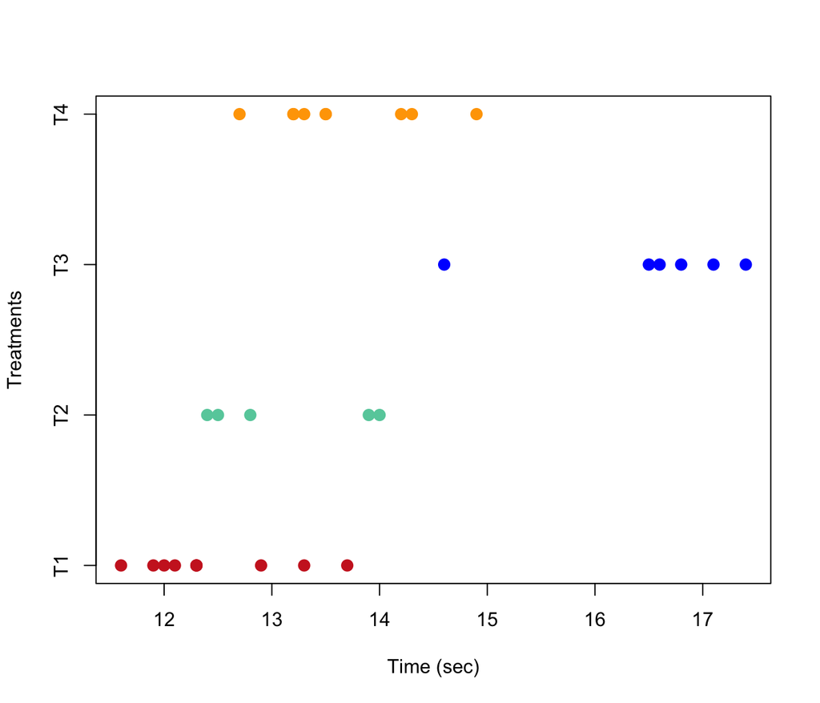

```r
x <- list("T1"=T1,"T2"=T2,"T3"=T3,"T4"=T4)

stripchart(x,col=c("firebrick3","aquamarine3","blue","orange"),
           pch=16,cex=1.4,xlab = "Time (sec)",ylab = "Treatments")
```

**ANSWER: The 4 group dotplot shows that there does look to be a difference in means between the groups. The groups have similar variability.**

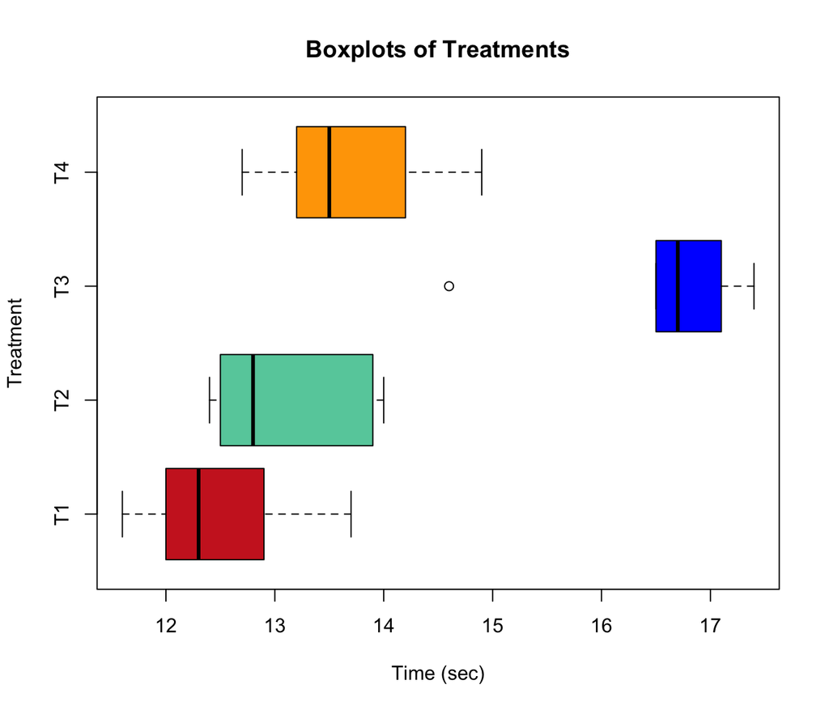

```r
percent<- c(T1, T2,T3,T4)
treatment<- c(rep("T1", 10), rep("T2", 5), rep("T3", 6), rep("T4",9))


boxplot(percent ~ treatment, main = "Boxplots of Treatments",
    xlab = "Time (sec)",col=c("firebrick3","aquamarine3","blue","orange"),
    horizontal=TRUE,ylab = "Treatment")
```

## `Step 3.` Checking of assumptions

### 1. Are the samples in each group simple random samples?

Yes. In a true experimental design like this situation, this assumption always met.

### 2. Are the variances equal in each group?

Yes. We will validate this assumption by using:

`Option 1:`

- For this example, the sample SDs for the four groups are 0.9879271, 0.7726578, 0.685768, and 0.6586181.

Is the largest no more than twice the smallest?

`Option 2`

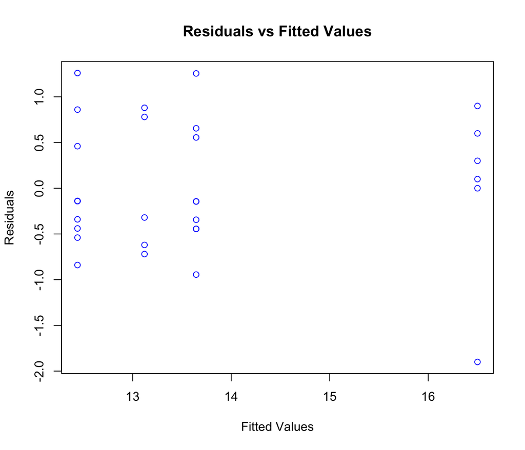

```r
mod1 <- aov(percent ~ treatment)
#evaluate residuals
plot(mod1$residuals ~ mod1$fitted, ylab = "Residuals",
xlab = "Fitted Values", main = "Residuals vs Fitted Values",col="blue")
```

The residuals vs. fitted values (sample means) plot shows reasonably `uniform spread`.

# 3. Check Assumptions: Normality

- The residuals come from a normal distribution population?

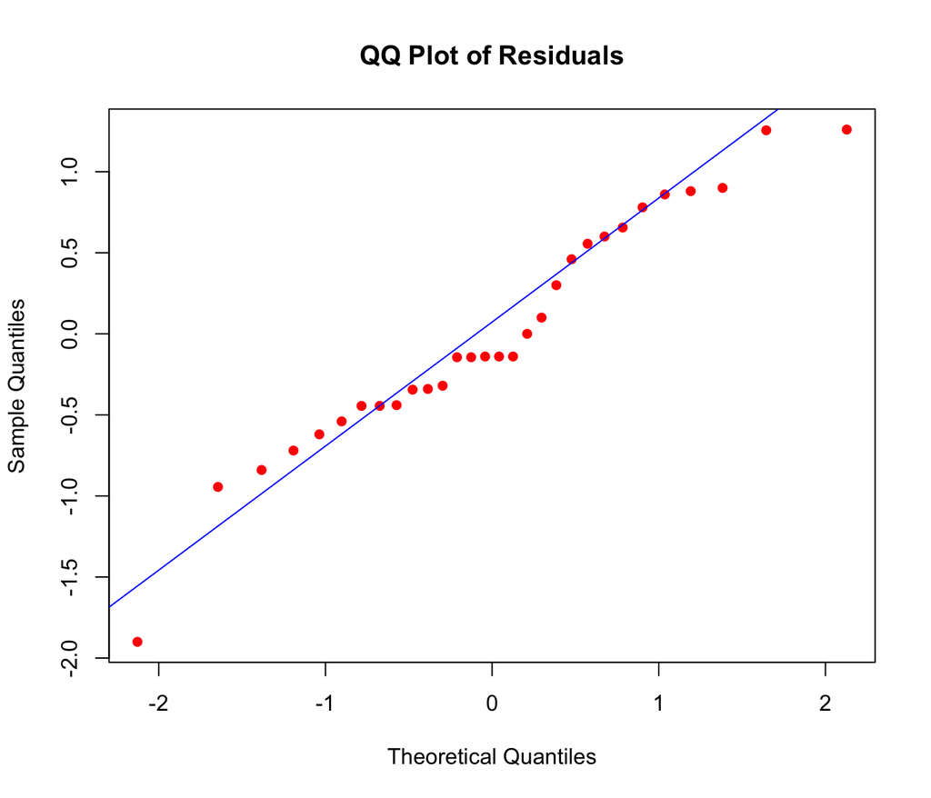

```r
qqnorm(residuals(mod1), main = "QQ Plot of Residuals",pch=16,col="red")
qqline(residuals(mod1), col="blue")
```

Everything looks fine here, and the normality assumption is met.

## 4. Check Assumptions: Independence

- Are the observations independent?

We will plot Residual vs. observations order.

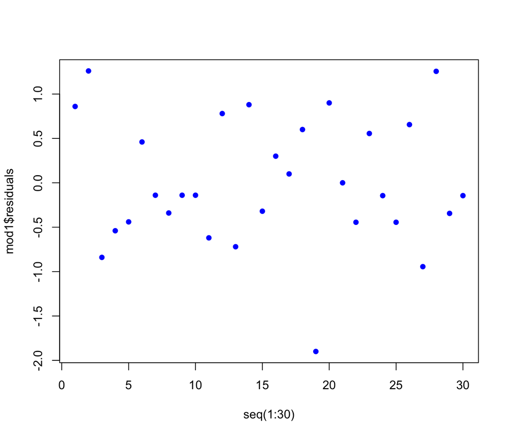

```r
plot(seq(1:30),mod1$residuals,col="blue",pch=16)
```

- We do not observe any pattern. Then, the independence assumption is met.

## `Step 4.` Perform the appropriated test statistic and make the decision

```r
mod1<- aov(percent ~ treatment)
anova(mod1)
```

|  | Df | Sum Sq | Mean Sq | F value | Pr(>F) |
| --- | --- | --- | --- | --- | --- |
| treatment | 3 | 64.60444 | 21.5348148 | 37.49142 | 1.370516e-09 |
| Residuals | 26 | 14.93422 | 0.5743932 | NA | NA |

$F=\frac{MST}{MSE}=\frac{21.53481}{0.574}=37.51709$ and p value =$P(F_{3,26}>37.51709) \approx 0$. This is very strong evidence against the null so we reject the null that all means are equal. This suggests a model that allows for multiple group means is preferable.

B. Conduct pairwise comparisons for all treatment pairs using $95\%$ CI based on Tukey method and Bonferroni using R. Make a table for each method to summarize your findings of which groups are found [statistically] significantly different.

`Solution`

TukeyHSD code below gives Tukey CIs.

- In R

```r
#get Tukey, only works with aov#
#gives only CIs and p-vals, not individual means#
TukeyHSD(mod1, conf.level = 0.95)
```

```
##   Tukey multiple comparisons of means
##     95% family-wise confidence level
##
## Fit: aov(formula = percent ~ treatment)
##
## $treatment
##             diff        lwr       upr     p adj
## T2-T1  0.6800000 -0.4587849  1.818785 0.3757811
## T3-T1  4.0600000  2.9863433  5.133657 0.0000000
## T4-T1  1.2044444  0.2491514  2.159738 0.0095551
## T3-T2  3.3800000  2.1210259  4.638974 0.0000005
## T4-T2  0.5244444 -0.6352373  1.684126 0.6074793
## T4-T3 -2.8555556 -3.9513519 -1.759759 0.0000008
```

```r
#to find Tukey multiplier#
qtukey(0.95, 4, 26) / sqrt(2)
```

```
## [1] 2.74332
```

We again see significant differences between groups 3 and 1, 4 and 1, 3 and 2, and 3 and 4.

## Bonferroni in R

```r
pairwise.t.test(percent, treatment, p.adjust.method = "bonf" )
```

```
##
##  Pairwise comparisons using t tests with pooled SD
##
## data:  percent and treatment
##
##    T1      T2      T3
## T2 0.681   -       -
## T3 5.9e-10 4.8e-07 -
## T4 0.011   1.000   8.2e-07
##
## P value adjustment method: bonferroni
```

```r
#or to find Bonferroni multiplier#
qt(1 - 0.05 / (2*6), 22)
```

```
## [1] 2.898537
```

After BF adjustment (multiplying pairwise comparison p values by 6), groups that have significant differences: 1 and 3; 1 and 4, 2 and 3, 3 and 4 which are the same pairs identified by the Tukey-Kramer CIs.